# Project: Communicate Data Findings (Baywheels tripdata)

## Introduction

This project has two parts that demonstrate the importance and value of data visualization techniques in the data analysis process.

This is the first part, here I will use Python visualization libraries to systematically **explore** a `Baywheels tripdata` dataset, starting from plots of single variables and building up to plots of multiple variables.

In the second part, I will produce a short presentation that illustrates interesting properties, trends, and relationships that you discovered in your selected dataset.(Provided in another file)

- Introduction
- Data Gathering
- Data Assessing
- Data Cleaning
- Data Exploration and Analysis
- Conclusion

## Data Gathering

> [Bay Wheels](https://www.lyft.com/bikes/bay-wheels) (previously known as Ford GoBike) is a regional public bike sharing system in San Francisco Bay Area, California. Bay Wheels is the first regional and large-scale bicycle sharing system deployed in California and on the West Coast of the United States with nearly 500,000 rides since the launch in 2017 and had about 10,000 annual subscribers as of January 2018. The dataset used for this exploratory analysis consists of Bay Wheels's trip data for public use for March 2020, which you can find [here](https://www.lyft.com/bikes/bay-wheels/system-data).

```python
# import all packages and set plots to be embedded inline
import numpy as np
import pandas as pd
import matplotlib.pyplot as plt
import seaborn as sb

%matplotlib inline
```

```python
# load dataset in dataframe
df = pd.read_csv('202003-baywheels-tripdata.csv')
```

## Data assessing

```python
df.head()
```

|  | duration_sec | start_time | end_time | start_station_id | start_station_name | start_station_latitude | start_station_longitude | end_station_id | end_station_name | end_station_latitude | end_station_longitude | bike_id | user_type | rental_access_method |
| --- | --- | --- | --- | --- | --- | --- | --- | --- | --- | --- | --- | --- | --- | --- |
| 0 | 35187 | 2020-03-31 20:42:10.0790 | 2020-04-01 06:28:37.8440 | 462.0 | Cruise Terminal at Pier 27 | 37.804648 | -122.402087 | 24.0 | Spear St at Folsom St | 37.789677 | -122.390428 | 10982 | Customer | NaN |
| 1 | 14568 | 2020-03-31 22:45:25.5010 | 2020-04-01 02:48:13.7730 | 42.0 | San Francisco City Hall (Polk St at Grove St) | 37.778650 | -122.418230 | 370.0 | Jones St at Post St | 37.787327 | -122.413278 | 12617 | Customer | NaN |
| 2 | 35990 | 2020-03-31 15:08:22.3310 | 2020-04-01 01:08:12.9900 | 391.0 | 1st St at Younger Ave | 37.355030 | -121.904436 | 397.0 | Gish Rd at 1st St | 37.361867 | -121.909315 | 12812 | Customer | NaN |
| 3 | 1068 | 2020-03-31 23:55:00.4260 | 2020-04-01 00:12:49.0200 | 456.0 | Arguello Blvd at Geary Blvd | 37.781468 | -122.458806 | 107.0 | 17th St at Dolores St | 37.763015 | -122.426497 | 12955 | Customer | NaN |
| 4 | 3300 | 2020-03-31 23:00:55.6410 | 2020-03-31 23:55:56.6110 | 6.0 | The Embarcadero at Sansome St | 37.804770 | -122.403234 | 24.0 | Spear St at Folsom St | 37.789677 | -122.390428 | 13050 | Customer | NaN |

```python
df.shape
```

```
(176799, 14)
```

```python
df.info()
```

```
<class 'pandas.core.frame.DataFrame'>
RangeIndex: 176799 entries, 0 to 176798
Data columns (total 14 columns):
 #   Column                   Non-Null Count   Dtype
---  ------                   --------------   -----
 0   duration_sec             176799 non-null  int64
 1   start_time               176799 non-null  object
 2   end_time                 176799 non-null  object
 3   start_station_id         110696 non-null  float64
 4   start_station_name       111349 non-null  object
 5   start_station_latitude   176799 non-null  float64
 6   start_station_longitude  176799 non-null  float64
 7   end_station_id           111097 non-null  float64
 8   end_station_name         111794 non-null  object
 9   end_station_latitude     176799 non-null  float64
 10  end_station_longitude    176799 non-null  float64
 11  bike_id                  176799 non-null  int64
 12  user_type                176799 non-null  object
 13  rental_access_method     114269 non-null  object
dtypes: float64(6), int64(2), object(6)
memory usage: 18.9+ MB
```

```python
df.describe()
```

|  | duration_sec | start_station_id | start_station_latitude | start_station_longitude | end_station_id | end_station_latitude | end_station_longitude | bike_id |
| --- | --- | --- | --- | --- | --- | --- | --- | --- |
| count | 176799.000000 | 110696.000000 | 176799.000000 | 176799.000000 | 111097.000000 | 176799.000000 | 176799.000000 | 176799.000000 |
| mean | 861.590156 | 185.082261 | 37.732506 | -122.339595 | 179.244228 | 37.731290 | -122.335029 | 332033.876114 |
| std | 1528.143090 | 154.647521 | 0.170476 | 0.336403 | 153.858017 | 0.278159 | 0.788013 | 310588.686471 |
| min | 60.000000 | 3.000000 | 0.000000 | -122.513814 | 3.000000 | 0.000000 | -122.529747 | 17.000000 |
| 25% | 374.000000 | 58.000000 | 37.763708 | -122.421339 | 53.000000 | 37.763848 | -122.420377 | 11695.000000 |
| 50% | 602.000000 | 125.000000 | 37.776598 | -122.403969 | 121.000000 | 37.776598 | -122.403234 | 299042.000000 |
| 75% | 963.000000 | 321.000000 | 37.789677 | -122.390648 | 309.000000 | 37.789747 | -122.390648 | 551560.000000 |
| max | 84450.000000 | 521.000000 | 37.880222 | 0.000000 | 521.000000 | 37.995942 | 0.000000 | 999960.000000 |

```python
df.duplicated().sum()
```

```
0
```

```python
df.user_type.value_counts()
```

```
Subscriber    96262
Customer      80537
Name: user_type, dtype: int64
```

```python
df.rental_access_method.value_counts()
```

```
app        105515
clipper      8754
Name: rental_access_method, dtype: int64
```

```python
df.isna().any()
```

```
duration_sec               False
start_time                 False
end_time                   False
start_station_id            True
start_station_name          True
start_station_latitude     False
start_station_longitude    False
end_station_id              True
end_station_name            True
end_station_latitude       False
end_station_longitude      False
bike_id                    False
user_type                  False
rental_access_method        True
dtype: bool
```

```python
df.isnull().sum()
```

```
duration_sec                   0
start_time                     0
end_time                       0
start_station_id           66103
start_station_name         65450
start_station_latitude         0
start_station_longitude        0
end_station_id             65702
end_station_name           65005
end_station_latitude           0
end_station_longitude          0
bike_id                        0
user_type                      0
rental_access_method       62530
dtype: int64
```

**There are some data quality issues such as**

- start_time and end_time columns are in string format instead of datetime format
- start_station_id, end_station_id are in float format instead of integer format
- user_type is in string format. Can be transformed into categorical variable
- *NULL* values in start_station_id, start_station_name, end_station_id, end_station_name and rental_access_method columns

### What is the structure of your dataset?

> Each trip is anonymized and includes:
- Trip Duration (seconds)
- Start Time and Date
- End Time and Date
- Start Station ID
- Start Station Name
- Start Station Latitude
- Start Station Longitude
- End Station ID
- End Station Name
- End Station Latitude
- End Station Longitude
- Bike ID
- User Type (Subscriber or Customer – “Subscriber” = Member or “Customer” = Casual)
- Rental access method(from app or clipper)

There are 176799 rows and 14 coloumns.

### What is/are the main feature(s) of interest in your dataset?

> - When are most trips taken in terms of time of day, day of the week, or month of the year?
> - Does the average duration depend on if a user is a subscriber or customer?

### What features in the dataset do you think will help support your investigation into your feature(s) of interest?

> - Trip Duration
> - Start TIme
> - End Time
> - User Type

## Data cleaning

```python
# make copy of data
df_clean = df.copy()
```

### Define

1. Drop rows with NULL values in start_station_id, start_station_name, end_station_id, end_station_name and rental_access_method columns

### Code

```python
df_clean.dropna(inplace=True)
```

### Test

```python
df_clean.info()
```

```
<class 'pandas.core.frame.DataFrame'>
Int64Index: 29557 entries, 63542 to 174729
Data columns (total 14 columns):
 #   Column                   Non-Null Count  Dtype
---  ------                   --------------  -----
 0   duration_sec             29557 non-null  int64
 1   start_time               29557 non-null  object
 2   end_time                 29557 non-null  object
 3   start_station_id         29557 non-null  float64
 4   start_station_name       29557 non-null  object
 5   start_station_latitude   29557 non-null  float64
 6   start_station_longitude  29557 non-null  float64
 7   end_station_id           29557 non-null  float64
 8   end_station_name         29557 non-null  object
 9   end_station_latitude     29557 non-null  float64
 10  end_station_longitude    29557 non-null  float64
 11  bike_id                  29557 non-null  int64
 12  user_type                29557 non-null  object
 13  rental_access_method     29557 non-null  object
dtypes: float64(6), int64(2), object(6)
memory usage: 3.4+ MB
```

```python
df_clean.isna().sum()
```

```
duration_sec               0
start_time                 0
end_time                   0
start_station_id           0
start_station_name         0
start_station_latitude     0
start_station_longitude    0
end_station_id             0
end_station_name           0
end_station_latitude       0
end_station_longitude      0
bike_id                    0
user_type                  0
rental_access_method       0
dtype: int64
```

### Define

1. convert data formats for start_time, end_time, start_station_id, end_station_id, user_type columns into correct one

### Code

```python
# convert datatype of start_time and end_time from object to datatime
df_clean['start_time']=pd.to_datetime(df_clean['start_time'])
df_clean['end_time'] = pd.to_datetime(df_clean['end_time'])

#  convert datatype of start_station_id and end_station_id to int
df_clean['start_station_id'] = df_clean['start_station_id'].astype('int')
df_clean['end_station_id'] = df_clean['end_station_id'].astype('int')

# convert datatype of user_type to category
df_clean['user_type'] = df_clean['user_type'].astype('category')
```

### Test

```python
df_clean.info()
```

```
<class 'pandas.core.frame.DataFrame'>
Int64Index: 29557 entries, 63542 to 174729
Data columns (total 14 columns):
 #   Column                   Non-Null Count  Dtype
---  ------                   --------------  -----
 0   duration_sec             29557 non-null  int64
 1   start_time               29557 non-null  datetime64[ns]
 2   end_time                 29557 non-null  datetime64[ns]
 3   start_station_id         29557 non-null  int32
 4   start_station_name       29557 non-null  object
 5   start_station_latitude   29557 non-null  float64
 6   start_station_longitude  29557 non-null  float64
 7   end_station_id           29557 non-null  int32
 8   end_station_name         29557 non-null  object
 9   end_station_latitude     29557 non-null  float64
 10  end_station_longitude    29557 non-null  float64
 11  bike_id                  29557 non-null  int64
 12  user_type                29557 non-null  category
 13  rental_access_method     29557 non-null  object
dtypes: category(1), datetime64[ns](2), float64(4), int32(2), int64(2), object(3)
memory usage: 3.0+ MB
```

### Define

1. extract date,day of the week,month,minute,hour from the start_time

### Code

```python
# Extract minute,day,week,month from the start_time
df_clean['duration_min'] = df_clean['duration_sec']/60

df_clean['start_date'] = df_clean.start_time.dt.strftime('%Y-%m-%d')
df_clean['start_hour_of_day'] = df_clean.start_time.dt.strftime('%H')
df_clean['start_day_of_week'] = df_clean.start_time.dt.strftime('%A')
df_clean['start_month'] = df_clean.start_time.dt.strftime('%B')
```

### Test

```python
df_clean.head()
```

|  | duration_sec | start_time | end_time | start_station_id | start_station_name | start_station_latitude | start_station_longitude | end_station_id | end_station_name | end_station_latitude | end_station_longitude | bike_id | user_type | rental_access_method | duration_min | start_date | start_hour_of_day | start_day_of_week | start_month |
| --- | --- | --- | --- | --- | --- | --- | --- | --- | --- | --- | --- | --- | --- | --- | --- | --- | --- | --- | --- |
| 63542 | 1772 | 2020-03-31 15:23:58 | 2020-03-31 15:53:30 | 473 | Willow St at Blewett Ave | 37.309014 | -121.900011 | 473 | Willow St at Blewett Ave | 37.309014 | -121.900011 | 480691 | Subscriber | app | 29.533333 | 2020-03-31 | 15 | Tuesday | March |
| 63543 | 737 | 2020-03-26 16:24:05 | 2020-03-26 16:36:23 | 473 | Willow St at Blewett Ave | 37.309014 | -121.900011 | 309 | San Jose City Hall | 37.337391 | -121.886995 | 237580 | Subscriber | app | 12.283333 | 2020-03-26 | 16 | Thursday | March |
| 63545 | 253 | 2020-03-15 18:51:36 | 2020-03-15 18:55:50 | 473 | Willow St at Blewett Ave | 37.309014 | -121.900011 | 415 | Delmas Ave at Virginia St | 37.319757 | -121.892999 | 239732 | Subscriber | app | 4.216667 | 2020-03-15 | 18 | Sunday | March |
| 63550 | 169 | 2020-03-31 15:20:10 | 2020-03-31 15:23:00 | 473 | Willow St at Blewett Ave | 37.309014 | -121.900011 | 473 | Willow St at Blewett Ave | 37.309014 | -121.900011 | 439978 | Subscriber | app | 2.816667 | 2020-03-31 | 15 | Tuesday | March |
| 63552 | 623 | 2020-03-07 18:31:26 | 2020-03-07 18:41:50 | 473 | Willow St at Blewett Ave | 37.309014 | -121.900011 | 406 | Parkmoor Ave at Race St | 37.316736 | -121.910005 | 168502 | Subscriber | app | 10.383333 | 2020-03-07 | 18 | Saturday | March |

```python
df_clean.info()
```

```
<class 'pandas.core.frame.DataFrame'>
Int64Index: 29557 entries, 63542 to 174729
Data columns (total 19 columns):
 #   Column                   Non-Null Count  Dtype
---  ------                   --------------  -----
 0   duration_sec             29557 non-null  int64
 1   start_time               29557 non-null  datetime64[ns]
 2   end_time                 29557 non-null  datetime64[ns]
 3   start_station_id         29557 non-null  int32
 4   start_station_name       29557 non-null  object
 5   start_station_latitude   29557 non-null  float64
 6   start_station_longitude  29557 non-null  float64
 7   end_station_id           29557 non-null  int32
 8   end_station_name         29557 non-null  object
 9   end_station_latitude     29557 non-null  float64
 10  end_station_longitude    29557 non-null  float64
 11  bike_id                  29557 non-null  int64
 12  user_type                29557 non-null  category
 13  rental_access_method     29557 non-null  object
 14  duration_min             29557 non-null  float64
 15  start_date               29557 non-null  object
 16  start_hour_of_day        29557 non-null  object
 17  start_day_of_week        29557 non-null  object
 18  start_month              29557 non-null  object
dtypes: category(1), datetime64[ns](2), float64(5), int32(2), int64(2), object(7)
memory usage: 4.1+ MB
```

```python
# save the cleaned data to csv file
df_clean.to_csv('baywheels_tripdata_clean.csv',index=None)
```

```python
trip_master=pd.read_csv('baywheels_tripdata_clean.csv')
trip_master.head()
```

|  | duration_sec | start_time | end_time | start_station_id | start_station_name | start_station_latitude | start_station_longitude | end_station_id | end_station_name | end_station_latitude | end_station_longitude | bike_id | user_type | rental_access_method | duration_min | start_date | start_hour_of_day | start_day_of_week | start_month |
| --- | --- | --- | --- | --- | --- | --- | --- | --- | --- | --- | --- | --- | --- | --- | --- | --- | --- | --- | --- |
| 0 | 1772 | 2020-03-31 15:23:58 | 2020-03-31 15:53:30 | 473 | Willow St at Blewett Ave | 37.309014 | -121.900011 | 473 | Willow St at Blewett Ave | 37.309014 | -121.900011 | 480691 | Subscriber | app | 29.533333 | 2020-03-31 | 15 | Tuesday | March |
| 1 | 737 | 2020-03-26 16:24:05 | 2020-03-26 16:36:23 | 473 | Willow St at Blewett Ave | 37.309014 | -121.900011 | 309 | San Jose City Hall | 37.337391 | -121.886995 | 237580 | Subscriber | app | 12.283333 | 2020-03-26 | 16 | Thursday | March |
| 2 | 253 | 2020-03-15 18:51:36 | 2020-03-15 18:55:50 | 473 | Willow St at Blewett Ave | 37.309014 | -121.900011 | 415 | Delmas Ave at Virginia St | 37.319757 | -121.892999 | 239732 | Subscriber | app | 4.216667 | 2020-03-15 | 18 | Sunday | March |
| 3 | 169 | 2020-03-31 15:20:10 | 2020-03-31 15:23:00 | 473 | Willow St at Blewett Ave | 37.309014 | -121.900011 | 473 | Willow St at Blewett Ave | 37.309014 | -121.900011 | 439978 | Subscriber | app | 2.816667 | 2020-03-31 | 15 | Tuesday | March |
| 4 | 623 | 2020-03-07 18:31:26 | 2020-03-07 18:41:50 | 473 | Willow St at Blewett Ave | 37.309014 | -121.900011 | 406 | Parkmoor Ave at Race St | 37.316736 | -121.910005 | 168502 | Subscriber | app | 10.383333 | 2020-03-07 | 18 | Saturday | March |

## Data Exploration and Analysis

> In this section, I used Python visualization libraries to systematically explore trip_master dataset, starting from plots of single variables and building up to plots of multiple variables. Also, some research questions were developed, which will be answered in the Data Analysis section.

### Univariate Exploration

```python
# lets look at the sample of our dataset
trip_master.sample(5)
```

|  | duration_sec | start_time | end_time | start_station_id | start_station_name | start_station_latitude | start_station_longitude | end_station_id | end_station_name | end_station_latitude | end_station_longitude | bike_id | user_type | rental_access_method | duration_min | start_date | start_hour_of_day | start_day_of_week | start_month |
| --- | --- | --- | --- | --- | --- | --- | --- | --- | --- | --- | --- | --- | --- | --- | --- | --- | --- | --- | --- |
| 26246 | 570 | 2020-03-13 15:45:25 | 2020-03-13 15:54:55 | 17 | Embarcadero BART Station (Beale St at Market St) | 37.792251 | -122.397086 | 104 | 4th St at 16th St | 37.767045 | -122.390833 | 332894 | Subscriber | app | 9.500000 | 2020-03-13 | 15 | Friday | March |
| 11249 | 2237 | 2020-03-23 17:50:36 | 2020-03-23 18:27:54 | 73 | Pierce St at Haight St | 37.771793 | -122.433708 | 73 | Pierce St at Haight St | 37.771793 | -122.433708 | 490328 | Subscriber | app | 37.283333 | 2020-03-23 | 17 | Monday | March |
| 10713 | 503 | 2020-03-07 20:08:26 | 2020-03-07 20:16:49 | 483 | 7th St at King St | 37.771229 | -122.400886 | 459 | Utah St at 24th St | 37.753123 | -122.405393 | 866166 | Subscriber | app | 8.383333 | 2020-03-07 | 20 | Saturday | March |
| 10348 | 826 | 2020-03-11 17:42:15 | 2020-03-11 17:56:01 | 93 | 4th St at Mission Bay Blvd S | 37.770407 | -122.391198 | 13 | Commercial St at Montgomery St | 37.794231 | -122.402923 | 519116 | Customer | app | 13.766667 | 2020-03-11 | 17 | Wednesday | March |
| 5581 | 838 | 2020-03-13 09:52:46 | 2020-03-13 10:06:45 | 109 | 17th St at Valencia St | 37.763316 | -122.421904 | 355 | 23rd St at Tennessee St | 37.755367 | -122.388795 | 859882 | Subscriber | app | 13.966667 | 2020-03-13 | 9 | Friday | March |

#### What is the distribution of the number of trips by the start hour of a day?

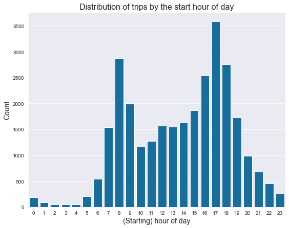

```python
# Visualizing distribution of trips by hours

plt.rcParams['figure.figsize'] = 9, 7
base_color = sb.color_palette('colorblind')[0]
sb.set_style('darkgrid')

sb.countplot(data=trip_master, x='start_hour_of_day', color=base_color)
plt.xlabel('(Starting) hour of day', fontsize=14)
plt.ylabel('Count', fontsize=14)
plt.title("Distribution of trips by the start hour of day", fontsize=16);
```

> The most busy hour is 5 PM, second busy hour is 8AM. The busy hours are 7-9 AM in morning and 4PM-6PM in the evening. This time is common commuting time.

#### What is the distribution of the number of trips by a day in a week?

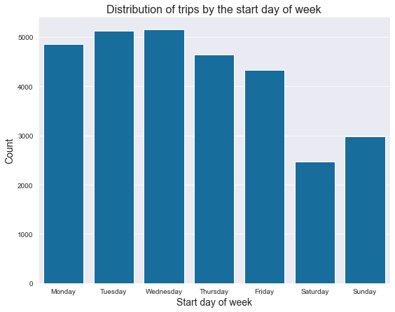

```python
# Visualizing distribution of trips by days

weekday = ['Monday', 'Tuesday', 'Wednesday', 'Thursday', 'Friday', 'Saturday', 'Sunday']
weekdaycat = pd.api.types.CategoricalDtype(ordered=True, categories=weekday)
trip_master['start_day_of_week'] = trip_master['start_day_of_week'].astype(weekdaycat)

sb.countplot(data=trip_master, x='start_day_of_week', color=base_color)
plt.xlabel('Start day of week', fontsize=14)
plt.ylabel('Count', fontsize=14)
plt.title("Distribution of trips by the start day of week", fontsize=16);
```

> People use the bike less on Saturday and Sunday.

What is the proportion between different user types?

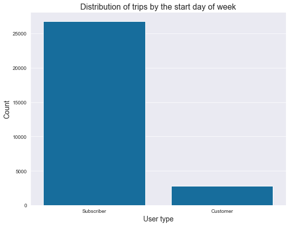

```python
# Let's have a look at the number of users by user type

sb.countplot(data=trip_master, x='user_type', color=base_color)
plt.xlabel('User type', fontsize=14)
plt.ylabel('Count', fontsize=14)
plt.title("Distribution of trips by the start day of week", fontsize=16);
```

> Majority of users are Subscribers.

#### What is the distribution between the rental access methods?

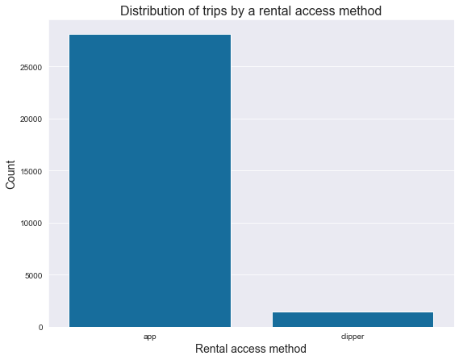

```python
# Let's have a look at the number of trips by rental access method

sb.countplot(data=trip_master, x='rental_access_method', color=base_color)
plt.xlabel('Rental access method', fontsize=14)
plt.ylabel('Count', fontsize=14)
plt.title("Distribution of trips by a rental access method", fontsize=16);
```

> Majority of the people rent via app.

#### How much time users spend in a trip?

[figure not shown]

```python
# Let's have a look at distribution of trips duration by minutes

plt.hist(data=trip_master, x='duration_minute')
plt.xlabel('Trip duration by minutes', fontsize=14)
plt.ylabel('Count', fontsize=14)
plt.title("Distribution of trips by trip durations in minutes", fontsize=16);
```

Let's assign appropriate bin size to get a better idea on the data

```python
trip_master['duration_min'].describe(percentiles=[.99])
```

```
count    29557.000000
mean        13.740487
std         14.722438
min          1.000000
50%         10.066667
99%         77.407333
max        470.833333
Name: duration_min, dtype: float64
```

```python
trip_master['duration_min'].describe()
```

```
count    29557.000000
mean        13.740487
std         14.722438
min          1.000000
25%          6.550000
50%         10.066667
75%         15.400000
max        470.833333
Name: duration_min, dtype: float64
```

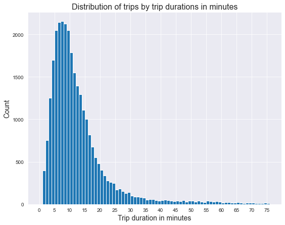

```python
# Revisualizing distribution of trips duration by minutes

bins = np.arange(0, 77, 1)
ticks = np.arange(0, 77, 5)
plt.hist(data=trip_master, x='duration_min', bins=bins)
plt.xticks(ticks, ticks)
plt.xlabel('Trip duration in minutes', fontsize=14)
plt.ylabel('Count', fontsize=14)
plt.title("Distribution of trips by trip durations in minutes", fontsize=16);
```

How many outliers we have for the trip duration?

```python
# Let's have a look at the outliers

trip_outliers = trip_master.query('duration_min >= 77')
trip_outliers.info()
```

```
<class 'pandas.core.frame.DataFrame'>
Int64Index: 303 entries, 183 to 29544
Data columns (total 19 columns):
 #   Column                   Non-Null Count  Dtype
---  ------                   --------------  -----
 0   duration_sec             303 non-null    int64
 1   start_time               303 non-null    object
 2   end_time                 303 non-null    object
 3   start_station_id         303 non-null    int64
 4   start_station_name       303 non-null    object
 5   start_station_latitude   303 non-null    float64
 6   start_station_longitude  303 non-null    float64
 7   end_station_id           303 non-null    int64
 8   end_station_name         303 non-null    object
 9   end_station_latitude     303 non-null    float64
 10  end_station_longitude    303 non-null    float64
 11  bike_id                  303 non-null    int64
 12  user_type                303 non-null    object
 13  rental_access_method     303 non-null    object
 14  duration_min             303 non-null    float64
 15  start_date               303 non-null    object
 16  start_hour_of_day        303 non-null    int64
 17  start_day_of_week        303 non-null    category
 18  start_month              303 non-null    object
dtypes: category(1), float64(5), int64(5), object(8)
memory usage: 45.6+ KB
```

We have 303 outliers in terms of duration of a trip

```python
trip_outliers.sample(10)
```

|  | duration_sec | start_time | end_time | start_station_id | start_station_name | start_station_latitude | start_station_longitude | end_station_id | end_station_name | end_station_latitude | end_station_longitude | bike_id | user_type | rental_access_method | duration_min | start_date | start_hour_of_day | start_day_of_week | start_month |
| --- | --- | --- | --- | --- | --- | --- | --- | --- | --- | --- | --- | --- | --- | --- | --- | --- | --- | --- | --- |
| 5016 | 6844 | 2020-03-20 18:27:13 | 2020-03-20 20:21:17 | 126 | Esprit Park | 37.761634 | -122.390648 | 126 | Esprit Park | 37.761634 | -122.390648 | 193388 | Subscriber | app | 114.066667 | 2020-03-20 | 18 | Friday | March |
| 11676 | 4715 | 2020-03-14 14:38:09 | 2020-03-14 15:56:45 | 364 | China Basin St at 3rd St | 37.772000 | -122.389970 | 512 | Divisadero St at Clay St | 37.789688 | -122.440688 | 451250 | Subscriber | app | 78.583333 | 2020-03-14 | 14 | Saturday | March |
| 17231 | 5307 | 2020-03-17 17:13:00 | 2020-03-17 18:41:28 | 52 | McAllister St at Baker St | 37.777416 | -122.441838 | 52 | McAllister St at Baker St | 37.777416 | -122.441838 | 120789 | Subscriber | app | 88.450000 | 2020-03-17 | 17 | Tuesday | March |
| 28482 | 5596 | 2020-03-22 11:31:54 | 2020-03-22 13:05:11 | 487 | Powell St at Columbus Ave | 37.800496 | -122.410887 | 487 | Powell St at Columbus Ave | 37.800496 | -122.410887 | 610909 | Customer | app | 93.266667 | 2020-03-22 | 11 | Sunday | March |
| 2589 | 9885 | 2020-03-09 12:30:56 | 2020-03-09 15:15:41 | 131 | 22nd St at Dolores St | 37.755000 | -122.425728 | 400 | Buchanan St at North Point St | 37.804272 | -122.433537 | 523836 | Subscriber | app | 164.750000 | 2020-03-09 | 12 | Monday | March |
| 6389 | 4643 | 2020-03-22 21:24:17 | 2020-03-22 22:41:41 | 114 | Rhode Island St at 17th St | 37.764478 | -122.402570 | 114 | Rhode Island St at 17th St | 37.764478 | -122.402570 | 551049 | Customer | app | 77.383333 | 2020-03-22 | 21 | Sunday | March |
| 28308 | 7078 | 2020-03-22 15:06:42 | 2020-03-22 17:04:40 | 8 | The Embarcadero at Vallejo St | 37.799953 | -122.398525 | 324 | Union Square (Powell St at Post St) | 37.788300 | -122.408531 | 650978 | Subscriber | app | 117.966667 | 2020-03-22 | 15 | Sunday | March |
| 29180 | 10183 | 2020-03-08 15:11:05 | 2020-03-08 18:00:48 | 400 | Buchanan St at North Point St | 37.804272 | -122.433537 | 16 | Market St at Steuart St | 37.794497 | -122.394838 | 921888 | Subscriber | app | 169.716667 | 2020-03-08 | 15 | Sunday | March |
| 24214 | 6926 | 2020-03-26 15:26:55 | 2020-03-26 17:22:22 | 324 | Union Square (Powell St at Post St) | 37.788300 | -122.408531 | 324 | Union Square (Powell St at Post St) | 37.788300 | -122.408531 | 577315 | Subscriber | app | 115.433333 | 2020-03-26 | 15 | Thursday | March |
| 24216 | 10267 | 2020-03-12 10:49:55 | 2020-03-12 13:41:02 | 324 | Union Square (Powell St at Post St) | 37.788300 | -122.408531 | 324 | Union Square (Powell St at Post St) | 37.788300 | -122.408531 | 546158 | Customer | app | 171.116667 | 2020-03-12 | 10 | Thursday | March |

When did the outlier cases happened?

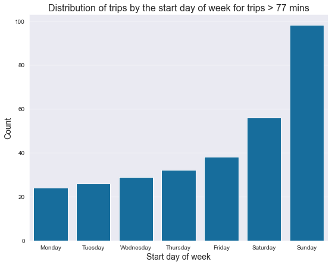

```python
# Visualizing distribution of trips by a day of week for the dataset with outliers

sb.countplot(data=trip_outliers, x='start_day_of_week', color=base_color)
plt.xlabel('Start day of week', fontsize=14)
plt.ylabel('Count', fontsize=14)
plt.title("Distribution of trips by the start day of week for trips > 77 mins", fontsize=16);
```

> It shows that people spend more time in bike during weekends.

At what time do we get the outlier cases?

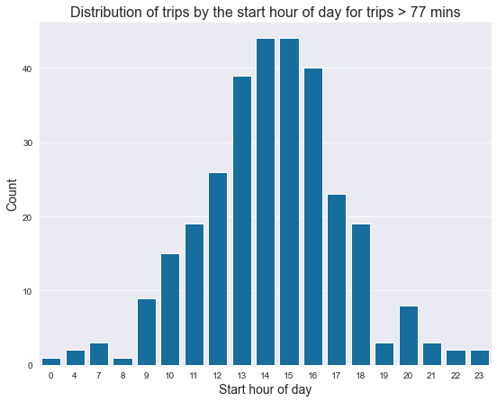

```python
# Visualizing distribution of trips by hours for the dataset with outliers

plt.rcParams['figure.figsize'] = 9, 7
base_color = sb.color_palette('colorblind')[0]
sb.set_style('darkgrid')

sb.countplot(data=trip_outliers, x='start_hour_of_day', color=base_color)
plt.xlabel('Start hour of day', fontsize=14)
plt.ylabel('Count', fontsize=14)
plt.title("Distribution of trips by the start hour of day for trips > 77 mins", fontsize=16);
```

> longer trips (>77 mins) will be more likely from 12 PM to 4 PM.

### Bivariate Exploration

How much time do each user group tend to spend in a trip? Is there any difference?

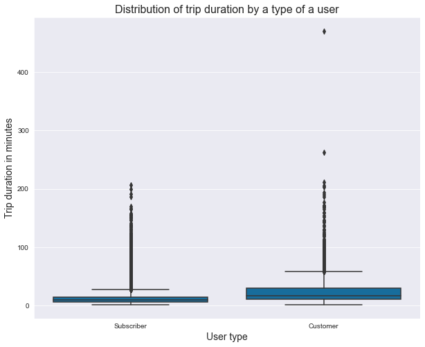

```python
# Let's have a look at how duration of a trip varies between different users

plt.rcParams['figure.figsize'] = 10, 8
sb.boxplot(data=trip_master, x='user_type', y='duration_min', color=base_color);
plt.xlabel('User type', fontsize=14)
plt.ylabel('Trip duration in minutes', fontsize=14)
plt.title("Distribution of trip duration by a type of a user", fontsize=16);
```

> Customers tend to use the service longer than subscribers. However, due to a disproportion between customers and subscribers in the dataset (subscribers is the majority), we may get incorrect view on the situation. It is better to gather data for a longer period of time to have a better understanding.

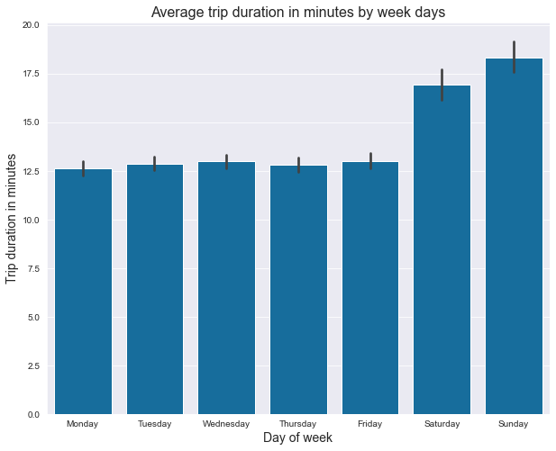

```python
# Trip duration by week days

sb.barplot(data=trip_master, x='start_day_of_week', y='duration_min', color=base_color)
plt.xlabel('Day of week', fontsize=14)
plt.ylabel('Trip duration in minutes', fontsize=14)
plt.title("Average trip duration in minutes by week days", fontsize=16);
```

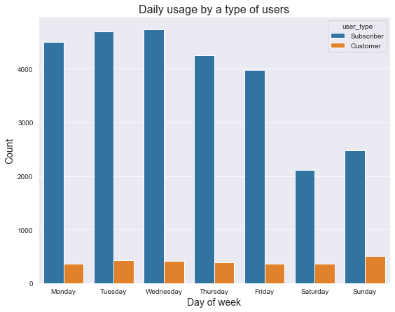

```python
# Daily usage by a user type

plt.rcParams['figure.figsize'] = 9, 7
sb.countplot(data=trip_master, x='start_day_of_week', hue='user_type');
plt.xlabel('Day of week', fontsize=14)
plt.ylabel('Count', fontsize=14)
plt.title("Daily usage by a type of users", fontsize=16);
```

Customers more tend to use the service during weekends, while subscribers prefer to cycle from Monday to Friday

Is there any difference in hourly usage between type of users?

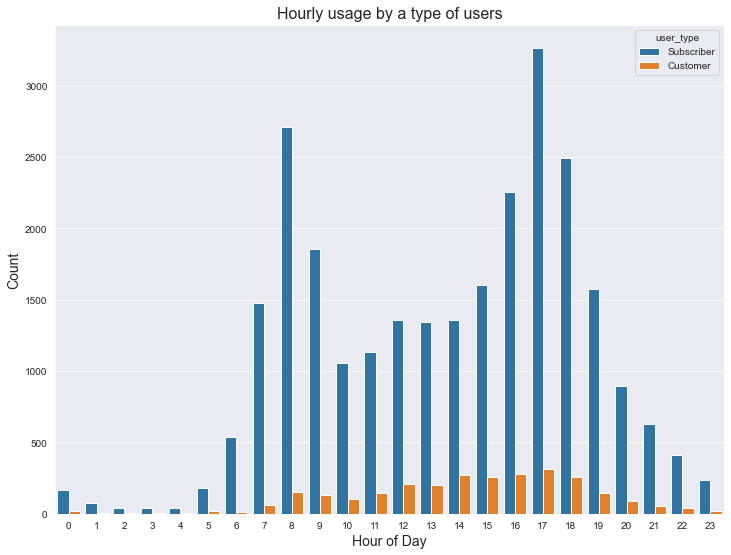

```python
# Hourly usage by a user type

plt.rcParams['figure.figsize'] = 12, 9
sb.countplot(data=trip_master, x='start_hour_of_day', hue='user_type');
plt.xlabel('Hour of Day', fontsize=14)
plt.ylabel('Count', fontsize=14)
plt.title("Hourly usage by a type of users", fontsize=16);
```

Is there any difference in daily usage between the access types?

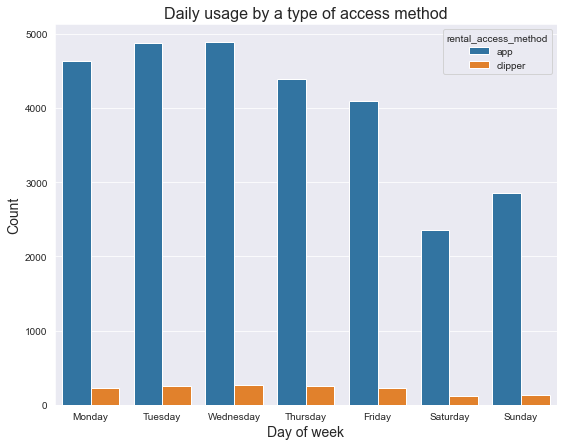

```python
# Daily usage by an access type

plt.rcParams['figure.figsize'] = 9, 7
sb.countplot(data=trip_master, x='start_day_of_week', hue='rental_access_method');
plt.xlabel('Day of week', fontsize=14)
plt.ylabel('Count', fontsize=14)
plt.title("Daily usage by a type of access method", fontsize=16);
```

There is a similar pattern in access method by a day of a week for each access method, where weekend looks less busy.

Is there any difference in hourly usage between the access types?

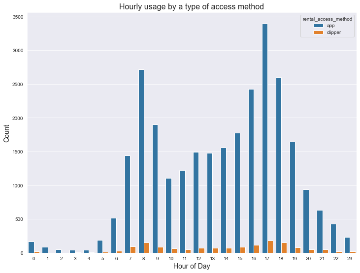

```python
# Hourly usage by a user type

plt.rcParams['figure.figsize'] = 12, 9
sb.countplot(data=trip_master, x='start_hour_of_day', hue='rental_access_method');
plt.xlabel('Hour of Day', fontsize=14)
plt.ylabel('Count', fontsize=14)
plt.title("Hourly usage by a type of access method", fontsize=16);
```

There is no difference in a hourly data usage by app and clipper access methods

## Multivariate Exploration

> Create plots of three or more variables to investigate your data even further. Make sure that your investigations are justified, and follow from your work in the previous sections.

**Q1: How does the average trip duration vary during a week between customers and subscribers?**

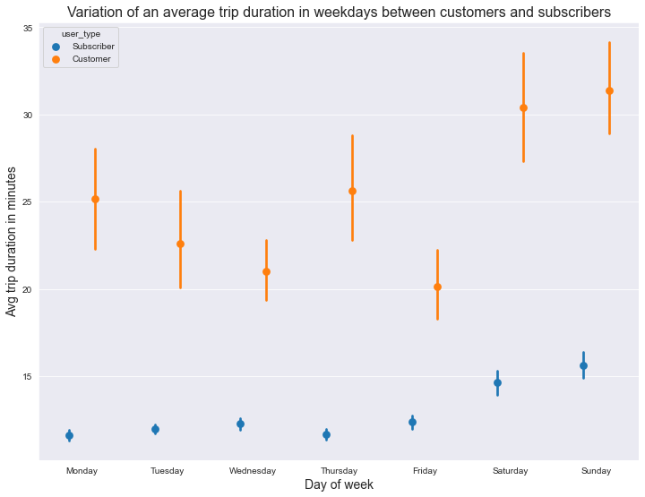

```python
sb.pointplot(data=trip_master, x='start_day_of_week', y='duration_min', hue='user_type', dodge=0.3, linestyles="")
plt.xlabel('Day of week', fontsize=14)
plt.ylabel('Avg trip duration in minutes', fontsize=14)
plt.title("Variation of an average trip duration in weekdays between customers and subscribers", fontsize=16);
```

**Q2: How does the average trip duration vary during a week between different access methods?**

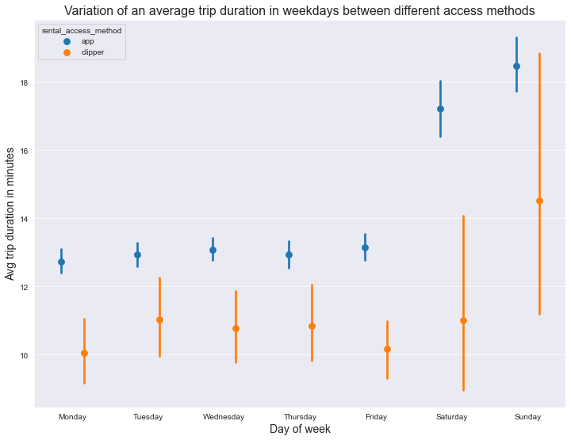

```python
# Visualization
sb.pointplot(data=trip_master, x='start_day_of_week', y='duration_min', hue='rental_access_method', dodge=0.3, linestyles="")
plt.xlabel('Day of week', fontsize=14)
plt.ylabel('Avg trip duration in minutes', fontsize=14)
plt.title("Variation of an average trip duration in weekdays between different access methods", fontsize=16);
```

Overall, users accessed by the app tend to spend more time in a trip. Also, it is clear that the trend for both accessing methods is increasing by the end of a week.

**Q3: How does the hourly usage vary during a week for customers and subscribers?**

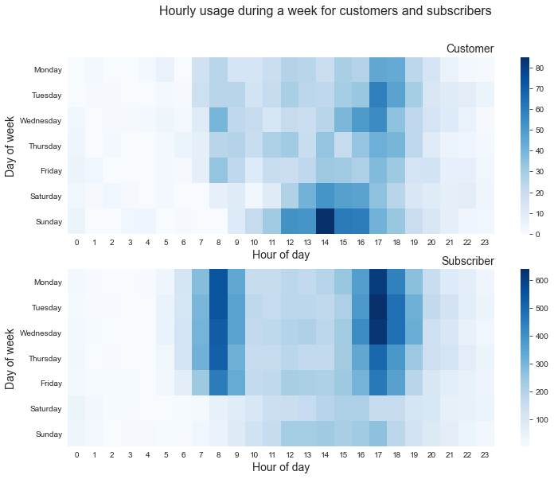

```python
plt.suptitle('Hourly usage during a week for customers and subscribers', fontsize=16)

plt.subplot(2, 1, 1)
customers = trip_master.query('user_type == "Customer"')
ct_counts = customers.groupby(['start_day_of_week', 'start_hour_of_day']).size()
ct_counts = ct_counts.reset_index(name='count')
ct_counts = ct_counts.pivot(index='start_day_of_week', columns='start_hour_of_day', values='count')
sb.heatmap(ct_counts, cmap="Blues");
plt.title('Customer', loc='right', fontsize=14);
plt.xlabel('Hour of day', fontsize=14);
plt.ylabel('Day of week', fontsize=14);

plt.subplot(2, 1, 2)
subscribers = trip_master.query('user_type == "Subscriber"')
st_counts = subscribers.groupby(['start_day_of_week', 'start_hour_of_day']).size()
st_counts = st_counts.reset_index(name='count')
st_counts = st_counts.pivot(index='start_day_of_week', columns='start_hour_of_day', values='count')
sb.heatmap(st_counts, cmap="Blues");
plt.title('Subscriber', loc='right', fontsize=14);
plt.xlabel('Hour of day', fontsize=14);
plt.ylabel('Day of week', fontsize=14);
```

It is interesting, that customers tend to use the bike service mostly on Sunday from 12 PM to 4 PM, while subscribers will likely have a trip from Monday to Friday during rush hours (7-9 AM, 4 PM - 6 PM).

**Q4: How does the hourly usage vary during a week for app and cleaper access methods?**

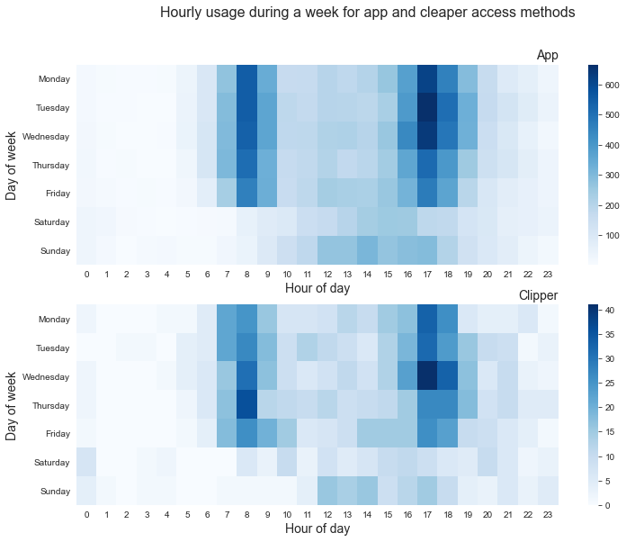

```python
plt.suptitle('Hourly usage during a week for app and cleaper access methods', fontsize=16)

plt.subplot(2, 1, 1)
customers = trip_master.query('rental_access_method == "app"')
ct_counts = customers.groupby(['start_day_of_week', 'start_hour_of_day']).size()
ct_counts = ct_counts.reset_index(name='count')
ct_counts = ct_counts.pivot(index='start_day_of_week', columns='start_hour_of_day', values='count')
sb.heatmap(ct_counts, cmap="Blues");
plt.title('App', loc='right', fontsize=14);
plt.xlabel('Hour of day', fontsize=14);
plt.ylabel('Day of week', fontsize=14);

plt.subplot(2, 1, 2)
subscribers = trip_master.query('rental_access_method == "clipper"')
st_counts = subscribers.groupby(['start_day_of_week', 'start_hour_of_day']).size()
st_counts = st_counts.reset_index(name='count')
st_counts = st_counts.pivot(index='start_day_of_week', columns='start_hour_of_day', values='count')
sb.heatmap(st_counts, cmap="Blues");
plt.title('Clipper', loc='right', fontsize=14);
plt.xlabel('Hour of day', fontsize=14);
plt.ylabel('Day of week', fontsize=14);
```

The access method does not have a significant influence on a day and time of usage the service.

## Conclusion

I tried to explore the trip data of Bay Wheels's bike sharing service and tried to answer appeared research questions using Python's visualization tools.

**Research questions and answers to them**:

**Q2: How does the average trip duration vary during a week between different access methods?**

Overall, users accessed by the app tend to spend more time in a trip. Also, it is clear that the trend for both accessing methods is increasing by the end of a week.

**Q3: How does the hourly usage vary during a week for customers and subscribers?**

It is interesting, that customers tend to use the bike service mostly on Sunday from 12 PM to 4 PM, while subscribers will likely have a trip from Monday to Friday during rush hours (7-9 AM, 4 PM - 6 PM).

**Q4: How does the hourly usage vary during a week for app and cleaper access methods?**

The access method does not have a significant influence on a day and time of usage the service. However, if we get more data on clipper access method, the pattern may change. As it was shown before, there is a lack of data on clipper usage type, which can be associated with some technical specifications/conditions of the service.